# Konsep Sistem Database

We are drowning for data, but starving for knowledge.  
- John Naisbitt

Alfa Nugraha Pradana

Prodi Statistika dan Sains Data IPB University

## Outline

- Terminologi
  - Data
  - Database
  - Metadata
  - Sistem Manajemen Database
- Data Model
- Skema
- Instance
- Elemen Database

# Terminologi

## Data

> Representasi objek dan kejadian yang direkam dalam bentuk angka, huruf, simbol, teks, gambar, video, bunyi, atau kombinasinya

[Satu Data Indonesia](https://satudata.go.id/tentang)

## Database

> Kumpulan data yang disusun dan saling berelasi serta disimpan dalam media penyimpanan tertentu secara bersama tanpa *redundancy* yang dapat dimanfaatkan kembali dengan cepat dan mudah

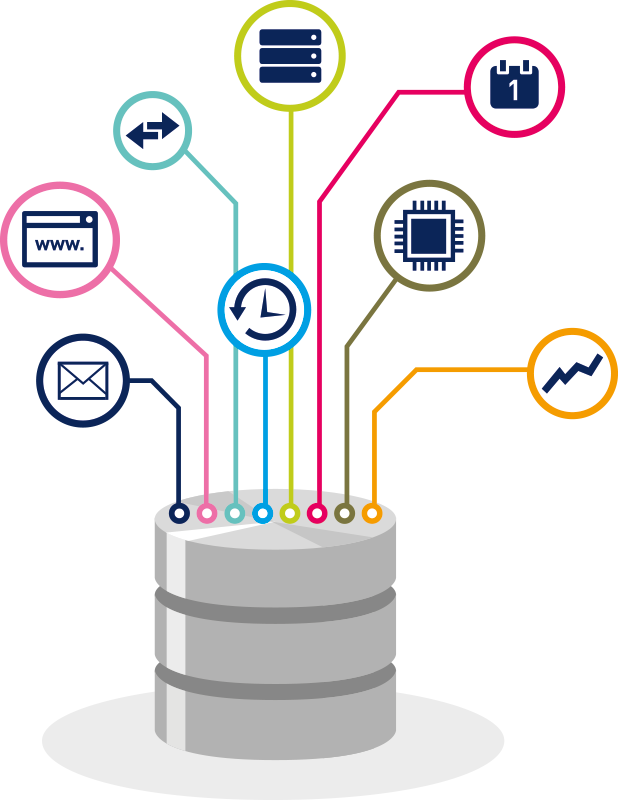

## Metadata

> Data yang menjelaskan ciri dan konteks data berdasarkan perspektif pengguna

`iris datasets`

| Sepal.Length | Sepal.Width | Petal.Length | Petal.Width | Species |
| --- | --- | --- | --- | --- |
| 5.1 | 3.5 | 1.4 | 0.2 | setosa |
| 4.9 | 3.0 | 1.4 | 0.2 | setosa |
| 4.7 | 3.2 | 1.3 | 0.2 | setosa |
| 4.6 | 3.1 | 1.5 | 0.2 | setosa |
| 5.0 | 3.6 | 1.4 | 0.2 | setosa |
| 5.4 | 3.9 | 1.7 | 0.4 | setosa |

`iris metadata`

| Column | DataType | Description |
| --- | --- | --- |
| Sepal.Length | double | panjang kelopak bunga |
| Sepal.Width | double | lebar kelopak bunga |
| Petal.Length | double | panjang mahkota bunga |
| Petal.Width | double | lebar mahkota bunga |
| Species | string | 3 spesies bunga |

## Sistem Manajemen Database

> Sistem perangkat lunak yang digunakan untuk membuat, memelihara, mengendalikan, dan menyediakan akses terhadap kepada sumber data dengan cara yang praktis dan efisien

Manfaat pendekatan basis data:

- Kecepatan dan kemudahan
- Kebersamaan pemakaian
- Pemusatan kontrol data
- Efisiensi ruang penyimpanan
- Keakuratan
- Ketersediaan
- Kelengkapan
- Keamanan
- Kemudahan dalam pembuatan program aplikasi baru
- *User view*

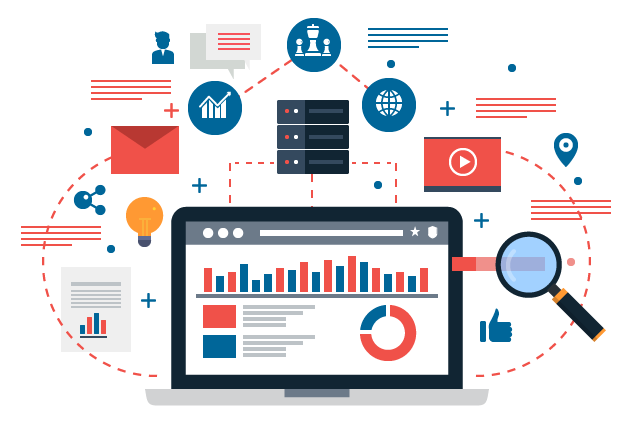

# Data Model, Skema, dan Instance

## Data Model

> Sekumpulan dari beberapa konsep yang dapat digunakan untuk mendeskripsikan struktur database

Terkadang kata **model** dinotasikan sebagai sebuah deskripsi database secara spesifik, atau ke dalam sebuah skema, sebagai contoh **model data pemasaran**

Banyak sekali data model yang sudah dikembangkan yang hingga saat ini dikenal dengan 3 kategori:

- High-level atau conceptual data models, menyediakan gambaran nyata yang sesuai dengan cara pandang pengguna
- Representational atau implementation data models, menyediakan gambaran mudah dipahami pengguna tetapi tidak menghilangkan unsur-unsur teknis yang digunakan pada penyimpanan data
- Low-level atau physical data models, menggambarkan secara detail bagaimana cara data disimpan pada media penyimpanan

Elmasri, R. Navathe, SB. . (2016). Fundamental Of Database Systems. 7th Edition. Pearson Higher Education.

## Skema

> Pada data model, sangat penting membedakan antara deskripsi database dengan database itu sendiri. Deskripsi dari suatu database disebut **skema database**, yang ditentukan pertama kali saat perancangan database dan tidak diharapkan banyak perubahan yang terjadi di dalamnya.

Diagram skema dapat digambarkan sebagai berikut

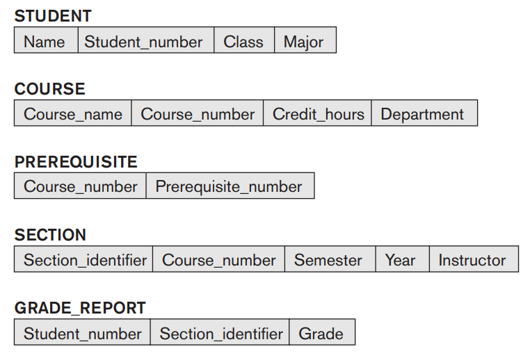

Elmasri, R. Navathe, SB. . (2016). Fundamental Of Database Systems. 7th Edition. Pearson Higher Education.

## Instance

[figure not shown]

Suatu diagram skema hanya menunjukkan beberapa aspek seperti nama dari masing-masing atribut data beserta aturannya, aspek lain terkadang tidak disertakan.

> Data yang ada di dalam database pada kurun waktu tertentu disebut *database state* atau *snapshot*, kadang lebih dikenal dengan **instance** sebagai gambaran kondisi data saat ini.

Elmasri, R. Navathe, SB. . (2016). Fundamental Of Database Systems. 7th Edition. Pearson Higher Education.

## Elemen Database

- **Data model**, menangkap sifat dan hubungan antar data dan digunakan berbagai kategori model saat database dirancang
- **Entitas**, menyusun atribut yang menggambarkan kata benda seperti orang, tempat, objek, kejadian
- **Relationships**, penghubung antar entitas, biasanya diilustrasikan dalam bentuk hubungan *one-to-many* atau *many-to-many*
- **Relasional database**, suatu database yang dibangun berdasarkan model relasi antar data

# Terima kasih

[figure not shown]

rpubs.com/alfanugraha/sta1562-p01